# Étude des caractéristiques de course

Observation statistique

Auteur·rice

Robin Maël

Date de publication

23 mars 2026

Mots clés

Amplitude, Fréquence, Sprint, Optimisation

# Observation Graphique

**DV**

**Razet**

#### Profil Amplitude - Fréquence

##### Graphiques

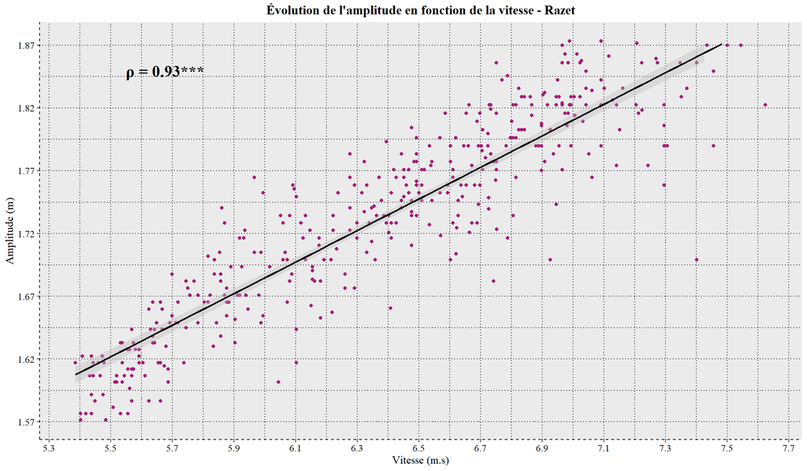

Graphique n°1 : Évolution de l’amplitude en fonction de la vitesse - Razet

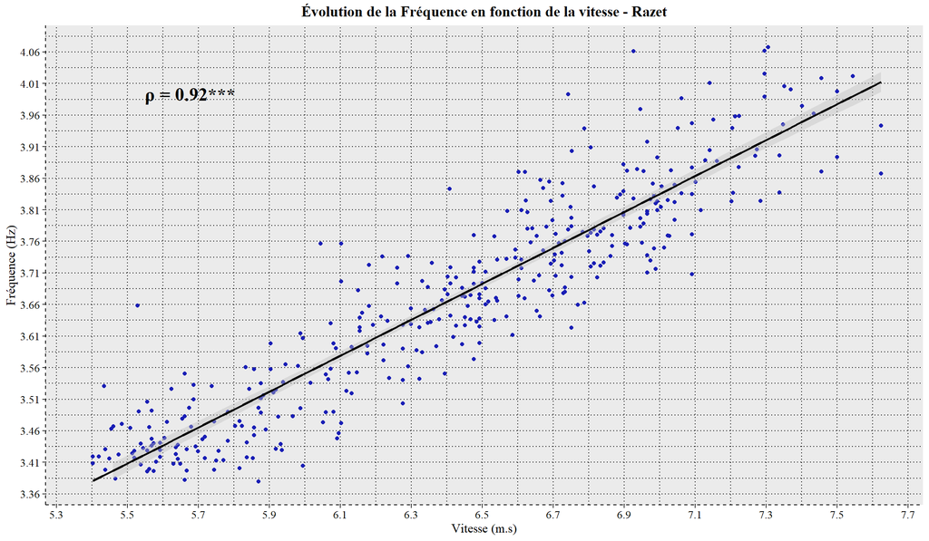

Graphique n°2 : Évolution de la Fréquence en fonction de la Vitesse - Razet

On observe de manière très **significative** une **corrélation forte positive** entre la **Vitesse** et l’**Amplitude**, et entre la **Vitesse** et la **Fréquence**.

On n’observe pas un profil plus porté vers l’Amplitude ou la Fréquence. C’est un profil mixte.

J’ai pas le profil F-V.

J’ai pas vérifié la normalité des données pour observer rapidement la tendance des résultats

J’ai posé :

- Si p < 0.001 = “***” ;
- Si p < 0.01 = “**” ;
- Si p < 0.05 = “*” ;
- Sinon p = “ns”

**Logette**

#### Profil Amplitude - Fréquence

##### Graphiques

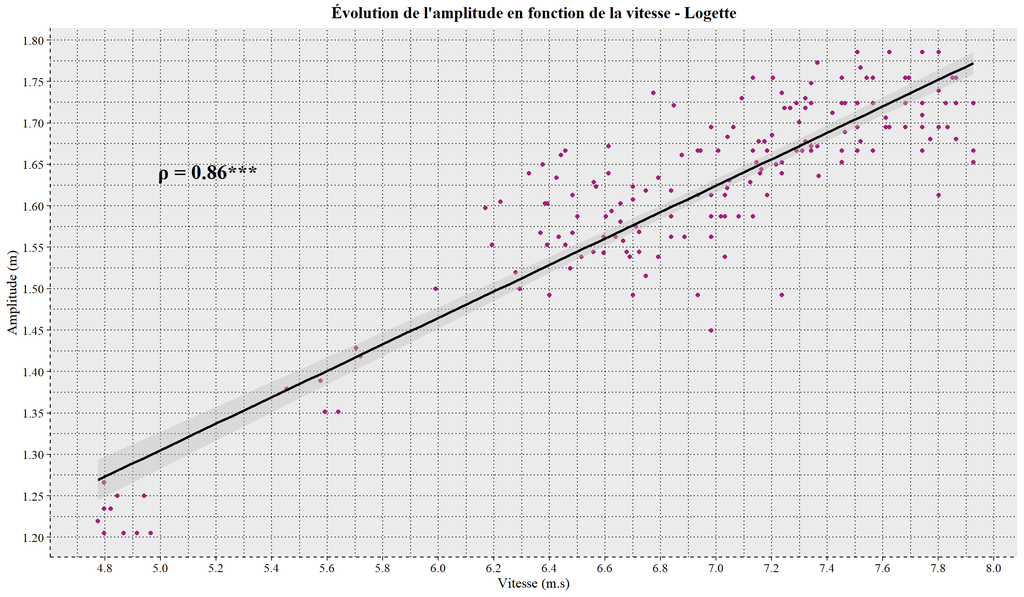

Graphique n°3 : Évolution de l’amplitude en fonction de la vitesse - Logette

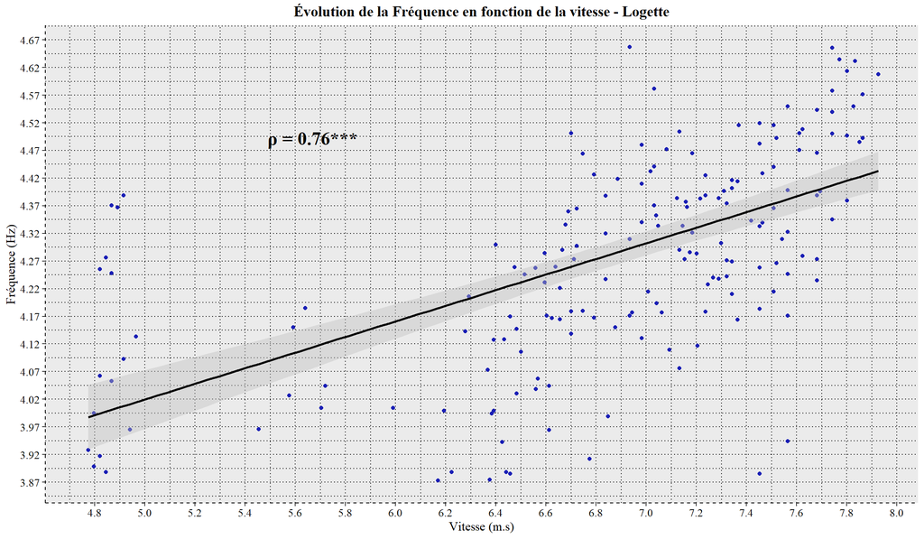

Graphique n°4 : Évolution de la Fréquence en fonction de la Vitesse - Logette

Chez Tiff on remarque des corrélations positives très significatives un peu moins fortes. On remarque que la corrélation est légèrement plus forte entre l’Amplitude et la Vitesse. Ce qui n’en fait pas pour autant un profil plus porté sur l’Amplitude. Surtout qu’on a pas raporté à la taille.

Le profil Force - Vitesse de Tiff c’est :

- VO : 8.18 m.s<sup>-1</sup>
- FO : 267 N
- F0.rel : 5.7 N.kg<sup>-1</sup>
- Pmax : 541 w
- Pmax.rel : 11.5 W.kg<sup>-1</sup>
- Vmax : 7.89 m.s<sup>-1</sup>

Comment je lie ces informations à mon profil de course ??

**Thebault**

#### Profil Amplitude - Fréquence

##### Graphiques

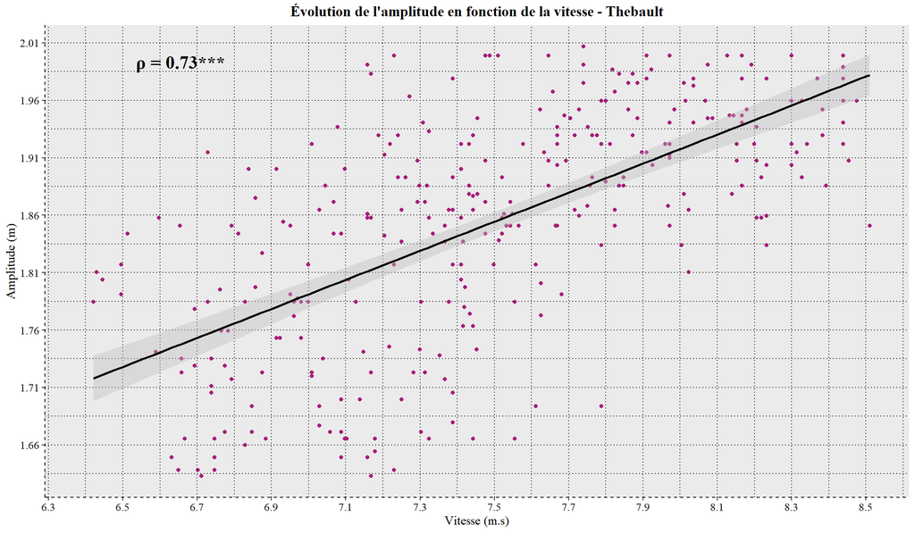

Graphique n°5 : Évolution de l’amplitude en fonction de la vitesse - Thebault

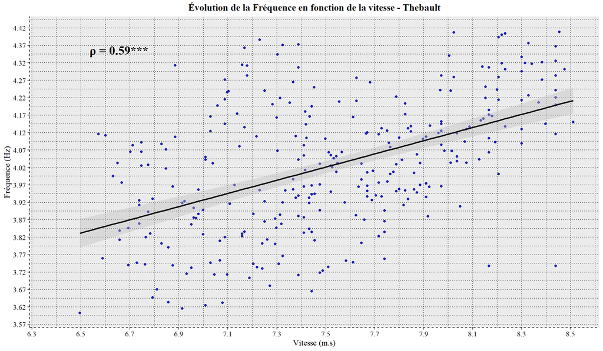

Graphique n°6 : Évolution de la Fréquence en fonction de la Vitesse - Thebault

Chez Evan on remarque encore des corrélations très significatives. Mais ici beaucoup moins marquées entre la Fréquence et la Vitesse. On peut se poser la question si Evan n’est pas un profil plus en Amplitude qu’en Fréquence.

Lucas m’a dit qu’il pouvait retrouver un Profil F-V de l’année dernière ou de l’année d’avant.

**Makunda**

#### Profil Amplitude - Fréquence

##### Graphiques

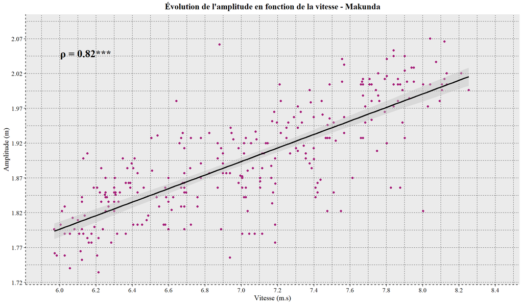

Graphique n°7 : Évolution de l’amplitude en fonction de la vitesse - Makunda

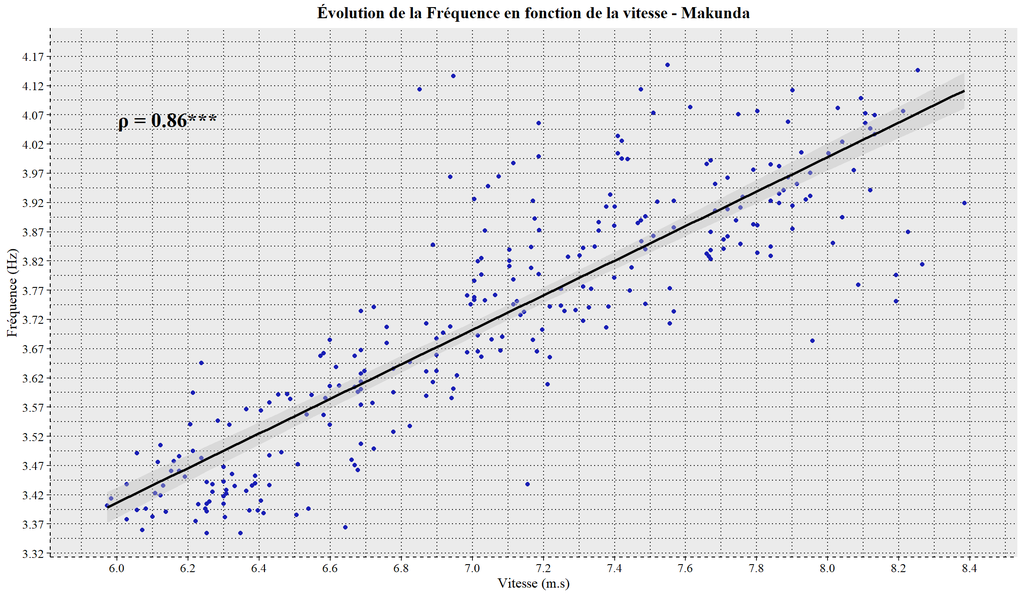

Graphique n°8 : Évolution de la Fréquence en fonction de la Vitesse - Makunda

Chez Trésor pour terminer on observe des corrélations positives très significatives. Les deux sont très fortes et quasi équivalentes.

On ne peut pas dégager non plus un profil particulier.

**Cumulé**

#### Profil Amplitude - Fréquence

##### Graphiques

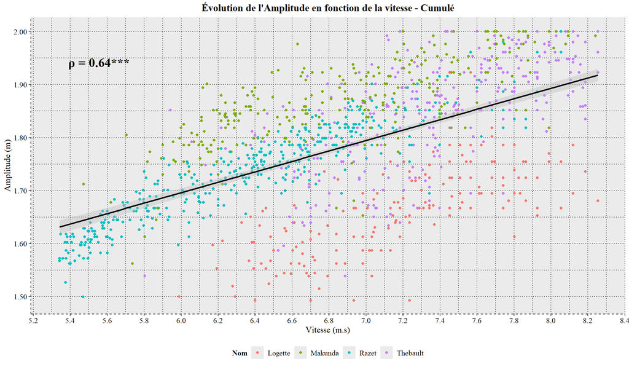

Graphique n°9 : Évolution de l’amplitude en fonction de la vitesse - Cumulé

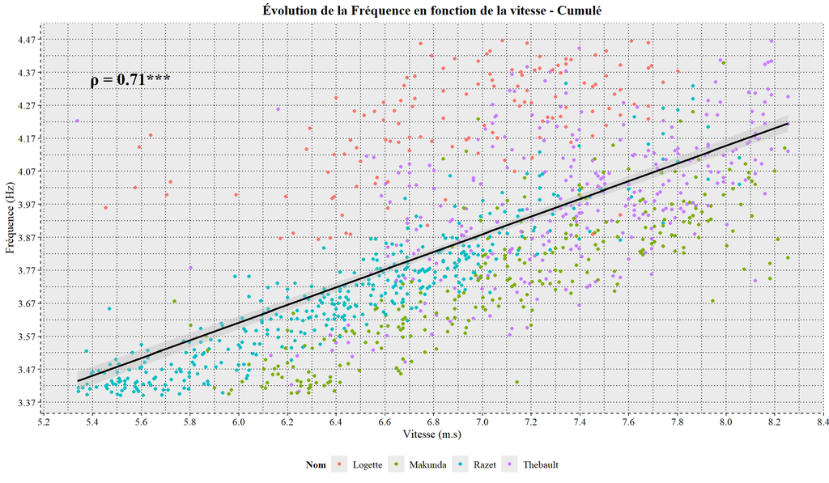

Graphique n°10 : Évolution de la Fréquence en fonction de la vitesse - Cumulé

**Guides**

**Mathonat**

#### Profil Amplitude - Fréquence

##### Graphiques

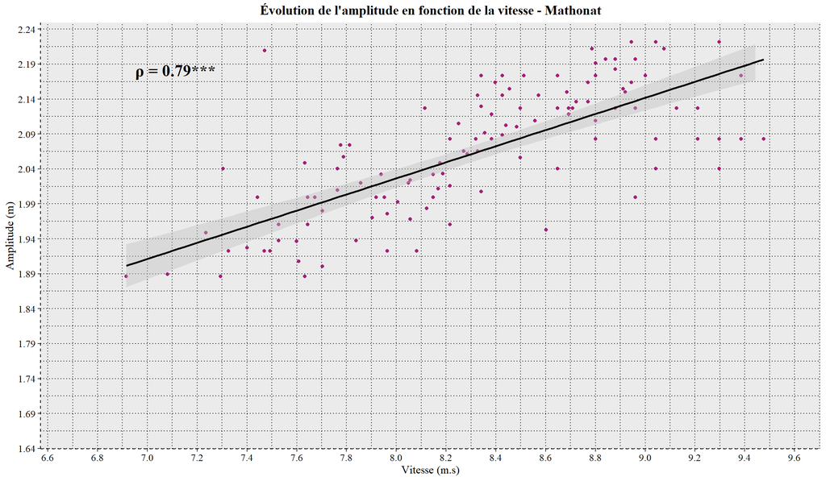

Graphique n°11 : Évolution de l’amplitude en fonction de la vitesse - Mathonat

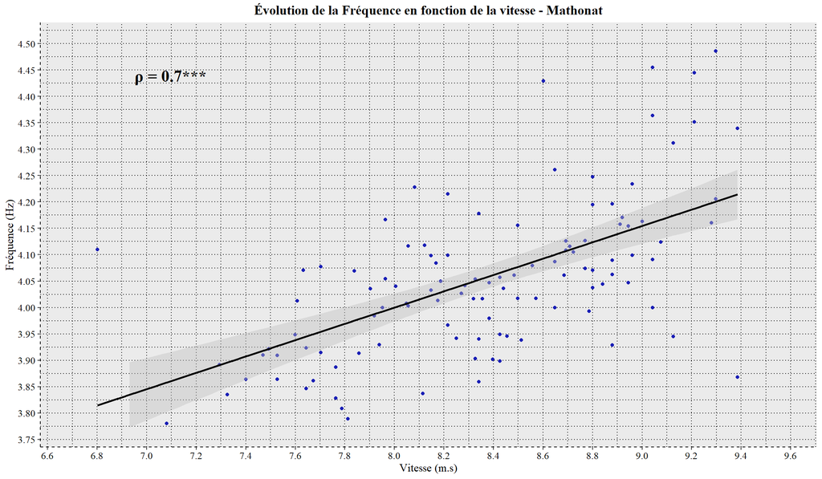

Graphique n°12 : Évolution de la Fréquence en fonction de la Vitesse - Mathonat

**Berland**

#### Profil Amplitude - Fréquence

##### Graphiques

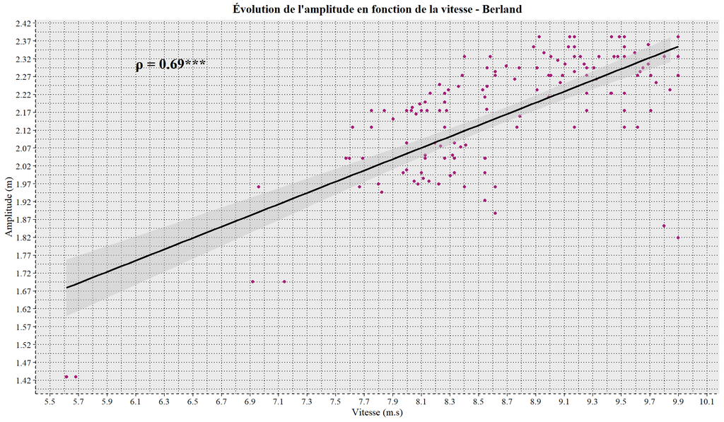

Graphique n°13 : Évolution de l’amplitude en fonction de la vitesse - Berland

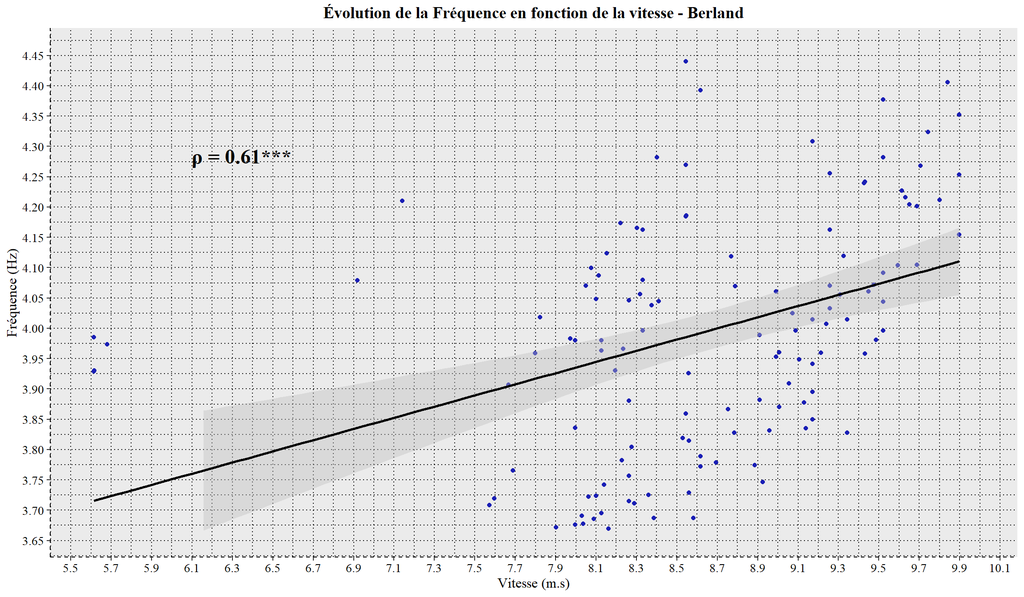

Graphique n°14 : Évolution de la Fréquence en fonction de la Vitesse - Berland